# Data Management and Visualization | Spring 2020 Midterm 02

Due: 12 june at 16:00

## Academic Honesty Statement

**THIS IS AN INDIVIDUAL ASSESSMENT, THIS DOCUMENT AND YOUR ANSWERS ARE FOR YOUR EYES ONLY. ANY VIOLATION OF THIS POLICY WILL BE IMMEDIATELY REPORTED TO THE MASTER CONDUCT BOARD.**

*Copy the text below, replacing the underscores with your name, and paste it in the report you submit, acknowledging that you have read and understood the abovementioned honesty statement.*

I, ____________, hereby state that I have not communicated with or gained information in any way from my classmates or anyone other than the Professors during this exam, and that all work is my own.

## Instructions

We expect you to produce a complete **knittable Rmarkdown document** that contains the text of the exercises, the code chunks needed to answer them, and **some comments on the results obtained**. There are **2 exercises** each one valued *5 points* apiece.

You will have a total of **1.5 hours** to complete the exam. During this time, we will be available in the forum of the virtual campus of the UdL to solve any doubt. Once the time has expired, we will access your RStudio Cloud project and **copy the Rmarkdown file as it is at that moment**, with no possibility of later changes. If you finish before the time allowed, please let us know. We will value not only the final result and the code, but also the appropriate formatting and coding style (see below).

Good luck to everyone!

## Data

For this midterm, we will analyze fire regimes in Spain, using the Spanish EGIF fire database. The main file we will use is the `fires` data frame, which contains information on each wildfire occurred in Spain since 1974. The dataset contains the following information:

- `CODCUAD`: Grid code. Associates fire occurrence to its spatial location.
- `IDPIF`: Fire identifire. Unique code to associate each fire event with the remaining information in the original database.
- `YEAR`: Year of occurrence.
- `MONTH`: Month of occurrence. Integer values from 1 to 12.
- `CAUSE`: Ignition source; 1-Natural; 2-Accident; 3-Negligence; 4-Arson; 5-Unknown; and 6-Restarted
- `BAREA`: burned area
- `CCAA`: Autonomous region where the fire started.

## Questions

The aim of this midterm exam is **to analyze, critisize and improve a set of plots** already designed. To do so, you have 2 figures. Figure 1 consists of 3 panels labeled as A, B and C. Figure 2 consists of 4 panels labeled according to the ignition source.

### Question 1

Two different researches have been working on visual representations of fire regimes in Spain. They have been instructed to conduct an analysis that reflects the temporal variability of burned area (both annual and monthly), paying special attention to the main sources of ignition.

You are in charge to decide which one of them (either Figure 1 or Figure 2) is the most appropriate and suggest any improvement to you deem necessary.

For each figure, you must write a brief report listing and discussing about the **main aesthetics involved** (e.g., `position`. Year was mapped into x-axis.). Then, suggest improvements for both figures and elaborate on which one works best and why (e.g., legends do not match, homogeneize color schemes).

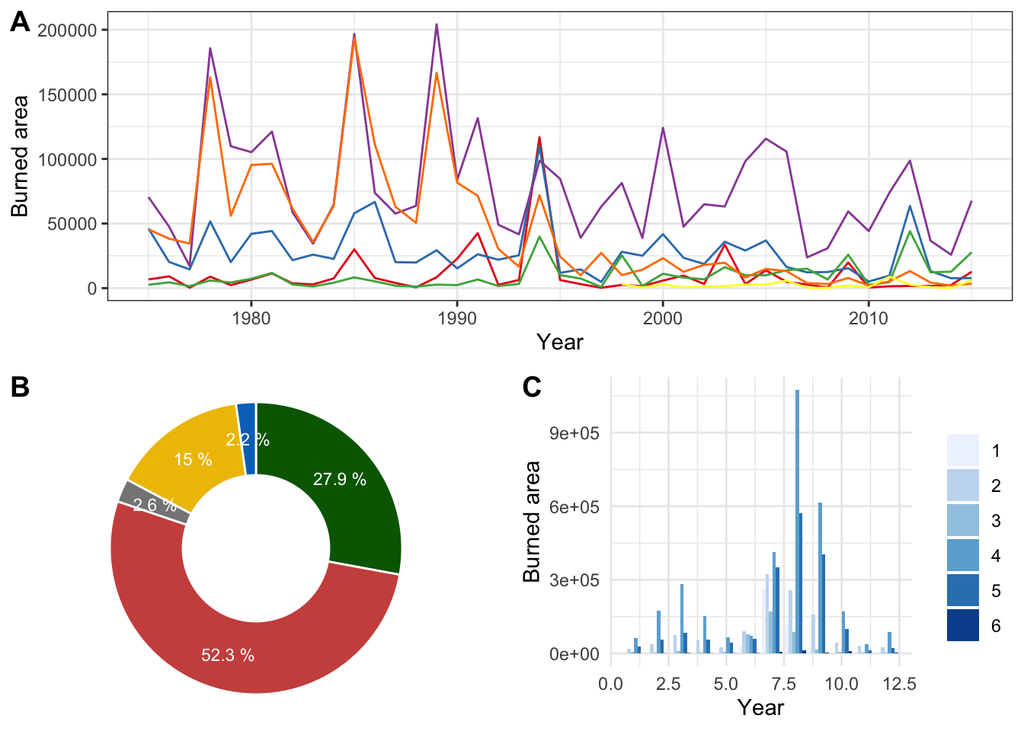

Figure 1: Summary of fire regimes in Spain. Color represents ignition source

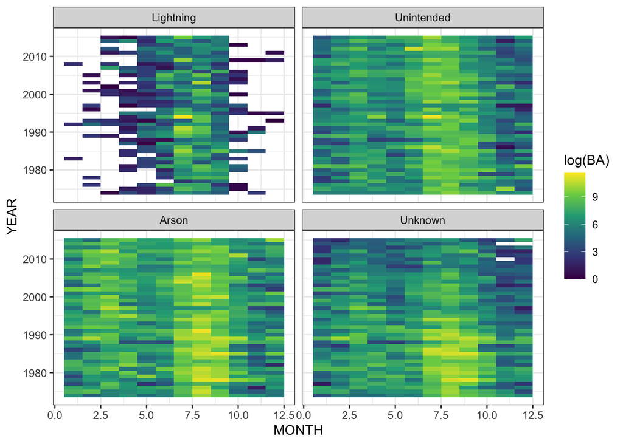

Figure 2: Summary of fire regimes in Spain. Color represents burned area in logarithmic scale

### Question 2

Now, you are going to take the role of one those two researches responsible for the figures in exercise 1. **Modify the code of the figure you thought it was the worst.** Try to follow your own advice and try to implement some of the improvements you have suggested. Explain how would you approach each change and, in case you don’t succeed, provide insights into the way you think the plot code should be modified.